# Project : Investigate a Dataset (TMDb Movie Data)

- Introduction
- Data Wrangling
- Exploratory Data Analysis
- Conclusions

## Introduction

> This dataset contains information about 10,000 movies, short films and tv series that collected from The Movie Database (TMDb), including user ratings and revenue,cast,release year.

>

> In this presentation, based on this dataset various questions will be answered for the curious minds.

> So i'll be answering the following questions:
> - Which Month Released more Movies ?
> - What are the most movies profitable to the market?
> - Which movies have the most and least profit?
> - What is the relationship between runtime and vote average?
> - Which years do movies made the most profits?
> - Most Frequent star cast?

```python
# import part :

import pandas as pd
import numpy as np
import matplotlib.pyplot as plt
import seaborn as sns
%matplotlib inline
```

## Data Wrangling

```python
# Loading the data and having a look at the first few lines
df_TMDb = pd.read_csv('tmdb-movies.csv')
df_TMDb.head()
```

|  | id | imdb_id | popularity | budget | revenue | original_title | cast | homepage | director | tagline | ... | overview | runtime | genres | production_companies | release_date | vote_count | vote_average | release_year | budget_adj | revenue_adj |
| --- | --- | --- | --- | --- | --- | --- | --- | --- | --- | --- | --- | --- | --- | --- | --- | --- | --- | --- | --- | --- | --- |
| 0 | 135397 | tt0369610 | 32.985763 | 150000000 | 1513528810 | Jurassic World | Chris Pratt\|Bryce Dallas Howard\|Irrfan Khan\|Vi... | http://www.jurassicworld.com/ | Colin Trevorrow | The park is open. | ... | Twenty-two years after the events of Jurassic ... | 124 | Action\|Adventure\|Science Fiction\|Thriller | Universal Studios\|Amblin Entertainment\|Legenda... | 6/9/15 | 5562 | 6.5 | 2015 | 1.379999e+08 | 1.392446e+09 |
| 1 | 76341 | tt1392190 | 28.419936 | 150000000 | 378436354 | Mad Max: Fury Road | Tom Hardy\|Charlize Theron\|Hugh Keays-Byrne\|Nic... | http://www.madmaxmovie.com/ | George Miller | What a Lovely Day. | ... | An apocalyptic story set in the furthest reach... | 120 | Action\|Adventure\|Science Fiction\|Thriller | Village Roadshow Pictures\|Kennedy Miller Produ... | 5/13/15 | 6185 | 7.1 | 2015 | 1.379999e+08 | 3.481613e+08 |
| 2 | 262500 | tt2908446 | 13.112507 | 110000000 | 295238201 | Insurgent | Shailene Woodley\|Theo James\|Kate Winslet\|Ansel... | http://www.thedivergentseries.movie/#insurgent | Robert Schwentke | One Choice Can Destroy You | ... | Beatrice Prior must confront her inner demons ... | 119 | Adventure\|Science Fiction\|Thriller | Summit Entertainment\|Mandeville Films\|Red Wago... | 3/18/15 | 2480 | 6.3 | 2015 | 1.012000e+08 | 2.716190e+08 |
| 3 | 140607 | tt2488496 | 11.173104 | 200000000 | 2068178225 | Star Wars: The Force Awakens | Harrison Ford\|Mark Hamill\|Carrie Fisher\|Adam D... | http://www.starwars.com/films/star-wars-episod... | J.J. Abrams | Every generation has a story. | ... | Thirty years after defeating the Galactic Empi... | 136 | Action\|Adventure\|Science Fiction\|Fantasy | Lucasfilm\|Truenorth Productions\|Bad Robot | 12/15/15 | 5292 | 7.5 | 2015 | 1.839999e+08 | 1.902723e+09 |
| 4 | 168259 | tt2820852 | 9.335014 | 190000000 | 1506249360 | Furious 7 | Vin Diesel\|Paul Walker\|Jason Statham\|Michelle ... | http://www.furious7.com/ | James Wan | Vengeance Hits Home | ... | Deckard Shaw seeks revenge against Dominic Tor... | 137 | Action\|Crime\|Thriller | Universal Pictures\|Original Film\|Media Rights ... | 4/1/15 | 2947 | 7.3 | 2015 | 1.747999e+08 | 1.385749e+09 |

5 rows × 21 columns

##### To see all information ( info for Rows and columns , info for data type ...)

```python
df_TMDb.shape
```

```
(10866, 21)
```

```python
df_TMDb.info()
```

```
<class 'pandas.core.frame.DataFrame'>
RangeIndex: 10866 entries, 0 to 10865
Data columns (total 21 columns):
 #   Column                Non-Null Count  Dtype
---  ------                --------------  -----
 0   id                    10866 non-null  int64
 1   imdb_id               10856 non-null  object
 2   popularity            10866 non-null  float64
 3   budget                10866 non-null  int64
 4   revenue               10866 non-null  int64
 5   original_title        10866 non-null  object
 6   cast                  10790 non-null  object
 7   homepage              2936 non-null   object
 8   director              10822 non-null  object
 9   tagline               8042 non-null   object
 10  keywords              9373 non-null   object
 11  overview              10862 non-null  object
 12  runtime               10866 non-null  int64
 13  genres                10843 non-null  object
 14  production_companies  9836 non-null   object
 15  release_date          10866 non-null  object
 16  vote_count            10866 non-null  int64
 17  vote_average          10866 non-null  float64
 18  release_year          10866 non-null  int64
 19  budget_adj            10866 non-null  float64
 20  revenue_adj           10866 non-null  float64
dtypes: float64(4), int64(6), object(11)
memory usage: 1.7+ MB
```

### Data Cleaning

In this part data cleaning will be performed. There are some columns indicating a problem. So they need to be cleaned in the first place.

##### First , check there is null value and solve it .

```python
df_TMDb.isnull().sum()
```

```
id                         0
imdb_id                   10
popularity                 0
budget                     0
revenue                    0
original_title             0
cast                      76
homepage                7930
director                  44
tagline                 2824
keywords                1493
overview                   4
runtime                    0
genres                    23
production_companies    1030
release_date               0
vote_count                 0
vote_average               0
release_year               0
budget_adj                 0
revenue_adj                0
dtype: int64
```

```python
df_TMDb.dropna(inplace=True )
```

```python
#checking there is null value
df_TMDb.isnull().sum().any()
```

```
False
```

##### Checking number of duplicates

```python
df_TMDb.duplicated().sum()
```

```
0
```

##### Dropping Columns:¶

> Remove columns that are not useful for answering questions (Homepage, Tagline, production_companies, Keywords and Overview)

```python
df_TMDb.drop(['homepage','tagline','production_companies','keywords','overview'], axis=1, inplace=True)
df_TMDb.columns
```

```
Index(['id', 'imdb_id', 'popularity', 'budget', 'revenue', 'original_title',
       'cast', 'director', 'runtime', 'genres', 'release_date', 'vote_count',
       'vote_average', 'release_year', 'budget_adj', 'revenue_adj'],
      dtype='object')
```

```python
# Explore dataset
df_TMDb.describe()
```

|  | id | popularity | budget | revenue | runtime | vote_count | vote_average | release_year | budget_adj | revenue_adj |
| --- | --- | --- | --- | --- | --- | --- | --- | --- | --- | --- |
| count | 1992.000000 | 1992.000000 | 1.992000e+03 | 1.992000e+03 | 1992.000000 | 1992.000000 | 1992.000000 | 1992.000000 | 1.992000e+03 | 1.992000e+03 |
| mean | 71652.152108 | 1.316763 | 3.454924e+07 | 1.152153e+08 | 106.040161 | 643.616968 | 6.178614 | 2007.796687 | 3.627376e+07 | 1.302391e+08 |
| std | 92355.883915 | 1.873563 | 5.061878e+07 | 2.202887e+08 | 29.234592 | 1092.355998 | 0.881955 | 7.549224 | 5.129783e+07 | 2.564338e+08 |
| min | 11.000000 | 0.000620 | 0.000000e+00 | 0.000000e+00 | 0.000000 | 10.000000 | 2.100000 | 1961.000000 | 0.000000e+00 | 0.000000e+00 |
| 25% | 9699.000000 | 0.384079 | 0.000000e+00 | 0.000000e+00 | 92.000000 | 51.000000 | 5.600000 | 2006.000000 | 0.000000e+00 | 0.000000e+00 |
| 50% | 35112.500000 | 0.774223 | 1.500000e+07 | 2.578782e+07 | 102.000000 | 210.000000 | 6.200000 | 2010.000000 | 1.524601e+07 | 2.806370e+07 |
| 75% | 83573.000000 | 1.538639 | 4.800000e+07 | 1.278787e+08 | 116.000000 | 688.250000 | 6.800000 | 2012.000000 | 5.064450e+07 | 1.393645e+08 |
| max | 414419.000000 | 32.985763 | 4.250000e+08 | 2.781506e+09 | 705.000000 | 9767.000000 | 8.300000 | 2015.000000 | 4.250000e+08 | 2.827124e+09 |

##### Filling 0 Values

```python
# Fill these in with the average of each column.
df_TMDb.budget_adj.mean()
```

```
36273759.3226546
```

```python
# Replace 0 values with mean.
df_TMDb.budget_adj= df_TMDb.budget_adj.replace(0, 36273759.3226546)
```

```python
#Checking if zero or less than zero
is_budget_adj_zero = df_TMDb['budget_adj'] == 0
df_TMDb[is_budget_adj_zero].shape ,df_TMDb[is_budget_adj_zero].index.values

df_TMDb[is_budget_adj_zero]
```

|  | id | imdb_id | popularity | budget | revenue | original_title | cast | director | runtime | genres | release_date | vote_count | vote_average | release_year | budget_adj | revenue_adj |
| --- | --- | --- | --- | --- | --- | --- | --- | --- | --- | --- | --- | --- | --- | --- | --- | --- |

```python
#Checking if zero or less than zero
is_runtime_zero = df_TMDb['runtime'] == 0
df_TMDb[is_runtime_zero].shape , df_TMDb[is_runtime_zero].index.values

df_TMDb[is_runtime_zero]
```

|  | id | imdb_id | popularity | budget | revenue | original_title | cast | director | runtime | genres | release_date | vote_count | vote_average | release_year | budget_adj | revenue_adj |
| --- | --- | --- | --- | --- | --- | --- | --- | --- | --- | --- | --- | --- | --- | --- | --- | --- |
| 334 | 361931 | tt5065822 | 0.357654 | 0 | 0 | Ronaldo | Cristiano Ronaldo | Anthony Wonke | 0 | Documentary | 11/9/15 | 80 | 6.5 | 2015 | 3.627376e+07 | 0.0 |
| 1289 | 286372 | tt1791681 | 0.037459 | 3250000 | 0 | Treehouse | J. Michael Trautmann\|Dana Melanie\|Daniel Fredr... | Michael G. Bartlett | 0 | Thriller\|Horror\|Mystery | 10/20/14 | 16 | 3.4 | 2014 | 2.993546e+06 | 0.0 |

```python
# Fill these in with the average of each column.
df_TMDb.runtime.mean()
```

```
106.04016064257029
```

```python
# Replace 0 values with mean.
df_TMDb.runtime= df_TMDb.runtime.replace(106.04016064257029)
```

```python
# Fill these in with the average of each column.
df_TMDb.revenue_adj.mean()
```

```
130239074.05593592
```

```python
df_TMDb.revenue_adj= df_TMDb.revenue_adj.replace(130239074.05593592)
```

```python
# Fill these in with the average of each column.
df_TMDb.budget.mean()
```

```
34549235.94076305
```

```python
df_TMDb.budget= df_TMDb.budget.replace(34549235.94076305)
```

#### Data split

```python
#make a function will will split the string and return the count of each genre.
def data(x):
    #concatenate all the rows of the genrs.
    data_plot = df_TMDb[x].str.cat(sep = '|')
    data = pd.Series(data_plot.split('|'))
    #conts each of the genre and return.
    info = data.value_counts(ascending=False)
    return info
```

##### Changing Datatypes, We have to convert release_date column to datetime as it is in object type.

```python
df_TMDb['release_date'] = pd.to_datetime(df_TMDb['release_date'])
```

##### Confirm if changes are done .¶

```python
df_TMDb.dtypes
```

```
id                         int64
imdb_id                   object
popularity               float64
budget                     int64
revenue                    int64
original_title            object
cast                      object
director                  object
runtime                    int64
genres                    object
release_date      datetime64[ns]
vote_count                 int64
vote_average             float64
release_year               int64
budget_adj               float64
revenue_adj              float64
dtype: object
```

## Exploratory Data Analysis

After cleanning the data and removed unnecessary information that might affect the data set. Now the data is ready to be used to answer questions, study the statistics and build visualization to study relationships between each others.

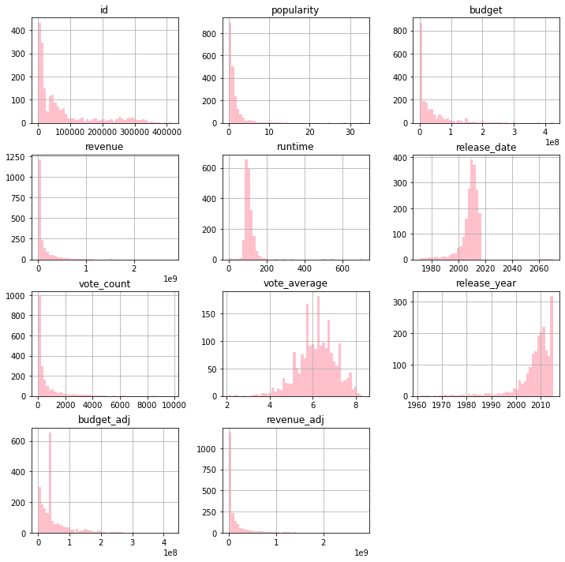

```python
# Preview overall distribution
df_TMDb.hist(figsize = (12,12), bins=50 ,color = 'pink');
```

### Research Question 1 :

### Which Month Released more Movies?

```python
# First, create a new column and put name "month".
# Then extract the best_month from release_date.

df_TMDb['month'] = df_TMDb['release_date'].apply(lambda x: x.month)
```

```python
df_TMDb.head(1)
```

[output not shown]

```python
#checking

df_TMDb.loc[:,"month"]
```

```
0         6
1         5
2         3
3        12
4         4
         ..
10724    12
10759    10
10760     7
10817     5
10819     7
Name: month, Length: 1992, dtype: int64
```

```python
number_of_release=df_TMDb['release_date'].dt.month.value_counts().sort_index()
number_of_release
```

```
1     149
2     122
3     151
4     137
5     158
6     157
7     153
8     153
9     290
10    201
11    146
12    175
Name: release_date, dtype: int64
```

### Plot these in chart.

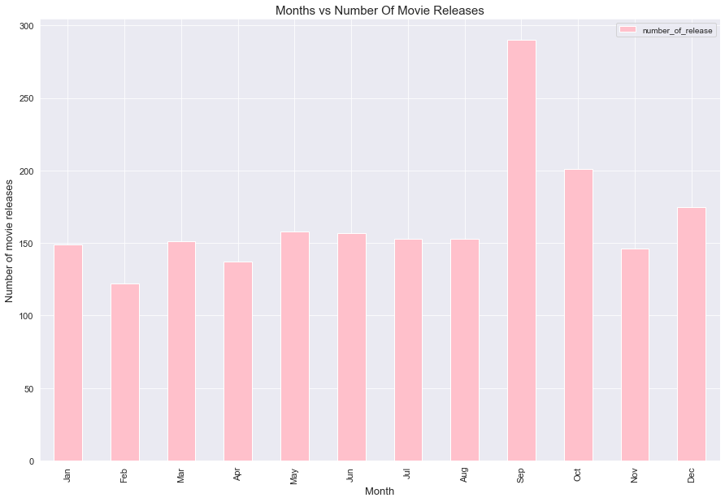

```python
months=['Jan','Feb','Mar','Apr','May','Jun','Jul','Aug','Sep','Oct','Nov','Dec']
number_of_release = pd.DataFrame(number_of_release)
number_of_release['month'] = months

#change the column name of the new dataframe 'number_of_release'

number_of_release.rename(columns = {'release_date':'number_of_release'},inplace=True)
number_of_release.plot(x='month',kind='bar',fontsize = 11,figsize=(15,10) , color='pink')

#set the labels and titles of the plot.
plt.title('Months vs Number Of Movie Releases',fontsize = 15)
plt.xlabel('Month',fontsize = 13)
plt.ylabel('Number of movie releases',fontsize = 13)
```

### Research Question 2

### What are the most movies profitable to the market?

```python
# Create new column for the profit to find out which movie is more successful.

df_TMDb['profit'] = df_TMDb['revenue'] - df_TMDb['budget']
df_TMDb['revenue'] = df_TMDb['revenue'].astype(int)
df_TMDb.head(1)
```

[output not shown]

```python
## show the top 5 rows.

df_TMDb.sort_values(['profit'], ascending = False).head(5)
```

|  | id | imdb_id | popularity | budget | revenue | original_title | cast | director | runtime | genres | release_date | vote_count | vote_average | release_year | budget_adj | revenue_adj | best_month | month | profit |
| --- | --- | --- | --- | --- | --- | --- | --- | --- | --- | --- | --- | --- | --- | --- | --- | --- | --- | --- | --- |
| 1386 | 19995 | tt0499549 | 9.432768 | 237000000 | 2781505847 | Avatar | Sam Worthington\|Zoe Saldana\|Sigourney Weaver\|S... | James Cameron | 162 | Action\|Adventure\|Fantasy\|Science Fiction | 2009-12-10 | 8458 | 7.1 | 2009 | 2.408869e+08 | 2.827124e+09 | 12 | 12 | 2544505847 |
| 3 | 140607 | tt2488496 | 11.173104 | 200000000 | 2068178225 | Star Wars: The Force Awakens | Harrison Ford\|Mark Hamill\|Carrie Fisher\|Adam D... | J.J. Abrams | 136 | Action\|Adventure\|Science Fiction\|Fantasy | 2015-12-15 | 5292 | 7.5 | 2015 | 1.839999e+08 | 1.902723e+09 | 12 | 12 | 1868178225 |
| 5231 | 597 | tt0120338 | 4.355219 | 200000000 | 1845034188 | Titanic | Kate Winslet\|Leonardo DiCaprio\|Frances Fisher\|... | James Cameron | 194 | Drama\|Romance\|Thriller | 1997-11-18 | 4654 | 7.3 | 1997 | 2.716921e+08 | 2.506406e+09 | 11 | 11 | 1645034188 |
| 0 | 135397 | tt0369610 | 32.985763 | 150000000 | 1513528810 | Jurassic World | Chris Pratt\|Bryce Dallas Howard\|Irrfan Khan\|Vi... | Colin Trevorrow | 124 | Action\|Adventure\|Science Fiction\|Thriller | 2015-06-09 | 5562 | 6.5 | 2015 | 1.379999e+08 | 1.392446e+09 | 6 | 6 | 1363528810 |
| 4 | 168259 | tt2820852 | 9.335014 | 190000000 | 1506249360 | Furious 7 | Vin Diesel\|Paul Walker\|Jason Statham\|Michelle ... | James Wan | 137 | Action\|Crime\|Thriller | 2015-04-01 | 2947 | 7.3 | 2015 | 1.747999e+08 | 1.385749e+09 | 4 | 4 | 1316249360 |

### Research Question 3

### Which movies have the most and least profit?

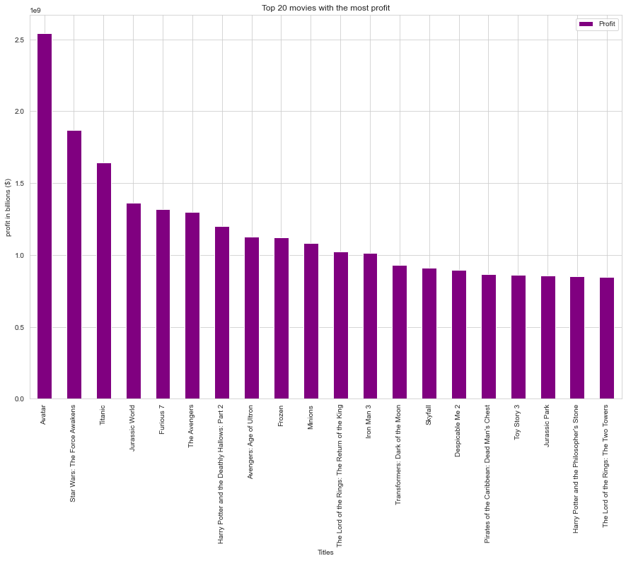

```python
# First sort the raw data by the profit.
sorted_profit = df_TMDb['profit'].sort_values(ascending=False)[:20]

# Create title and profit lists which will be used as X-axis and Y-axis values in bar graph.
high_profit=pd.DataFrame()
titles=[]
profit=[]

# Fill the vallues from raw data to the lists.
for i in sorted_profit.index:
    titles.append(df_TMDb.loc[i,'original_title'])
    profit.append(sorted_profit.loc[i])
high_profit['Titles']=titles
high_profit['Profit']=profit
high_profit.set_index('Titles',inplace=True)

# Plot
high_profit.plot(kind ='bar',figsize=(15,10) , color= 'purple')
plt.title('Top 20 movies with the most profit');
plt.ylabel('profit in billions ($)');
sns.set_style('darkgrid')
```

### Research Question 4

### What is the relationship between runtime and vote average?

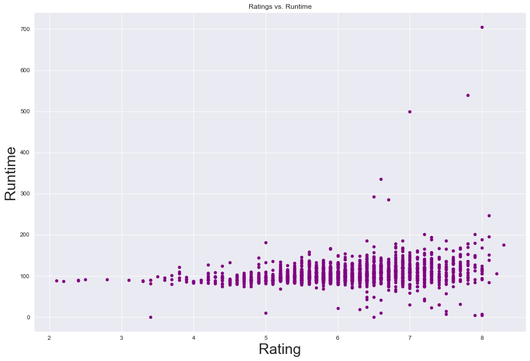

```python
# Plot scatter plot of these two columns
df_TMDb.plot(x='vote_average', y='runtime', kind='scatter', figsize=(15,10), color = 'purple')
plt.title('Ratings vs. Runtime')
plt.xlabel('Rating', size='25')
plt.ylabel('Runtime' ,size='25');
```

### Research Question 5

### Which years do movies made the most profits?

```python
# group total profit by each years
profit_year = df_TMDb.groupby('release_year')['profit'].sum()
profit_year.head(5)
```

```
release_year
1961      1000000
1962     58500000
1963     76398765
1964    121900549
1965    130195658
Name: profit, dtype: int64
```

### plot chart

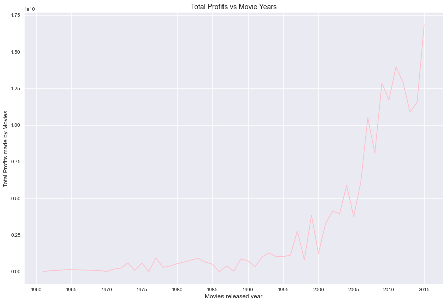

```python
profit_year.plot(xticks = np.arange(1960,2016,5),figsize = (15,10), color ='pink')
plt.xlabel('Movies released year', fontsize = 12)
plt.ylabel('Total Profits made by Movies', fontsize = 12)
plt.title('Total Profits vs Movie Years', fontsize = 14);
#set the style sheet
sns.set_style("whitegrid")
```

### Research Question 5

### Most Frequent star cast?

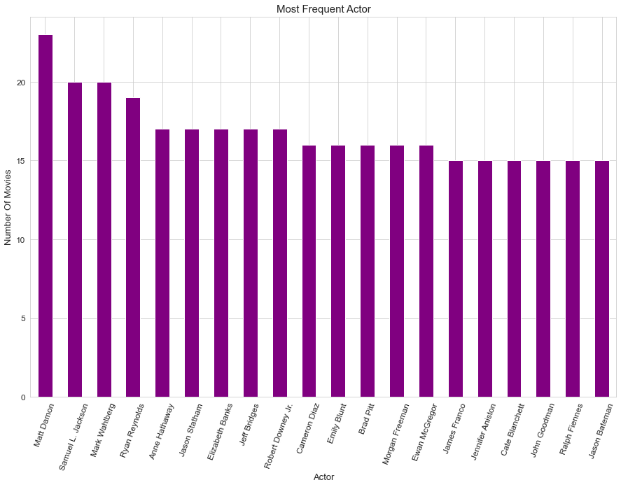

```python
#call the 'data' function which we made earlier for spiliing and counting genres.
#it wiil count number of movies done by each actor.

count_actor_flims = data('cast')

#plot the barh plot.
count_actor_flims.iloc[:20].plot.bar(figsize=(15,10),colormap= 'tab20c',fontsize=12 , color='purple')

#setup the title and the labels of the plot.
plt.title("Most Frequent Actor",fontsize=15)
plt.xticks(rotation = 70)
plt.xlabel('Actor',fontsize=13)
plt.ylabel("Number Of Movies",fontsize= 13)
sns.set_style("whitegrid")
```

## Conclusions

> like we seen in our data:

> 1- The higher number of release movies in september and october month.

> 2- The top 20 movies with the most earned profit. Clearly these titles are well knowed. Avatar is at tops 1, which profit exceded way more than the following movies.

> 3- We see again, Avatar earns the most profit . The function makes sense when comparing to the overall stats again. . It shows that great movie requires lots of efforts.

> 4- The ratings of Movies with a runtime of around 100 minutes are unpredictable, as they can run from low to high. Films/shows with a runtime above or below 100 minues tend to have mid-to-high ratings.

### Sources.

> - Pandas documents
> - Kaggle guide
> - github project
> - Towards, Data Science